# The Blue Zones: Why do some areas of the world have higher life expectancies than others?

Group 9

2022-11-22

## 0.1 Questions we cover in the project

> 1. A statement of the question or purpose. What problems or questions did you set out to analyse? What were the key issues raised?
1. Our goal is to analyze different factors, such as; nutrition, lifestyle, exercise, climate, genetics, hygiene,… and the impact they have on longevity in different parts of the world.

More specifically we aim to answer these questions:

1. Why do people living in blue zones live longer than others ?
2. How and why did longevity change over time for these countries ?
3. Which factors have the biggest influence on life expectancy ?
> 2. The background and preparation for conducting the project. How did you prepare for the project? What sources or background readings did you consult? What information did you use in developing your ideas from the conceptual stage to the finished project?

We read through some articles about Blue Zones. Blue zones are regions in the world where people are speculated to live longer than average; the term was coined by Gianni Pes, Michel Poulain and Dan Buettner. There are five blues zones: Okinawa (Japan), Sardinia (Italy), Nicoya (Costa Rica), Icaria (Greece) and Loma Linda (California). We also looked up some research about some potential factors that could contribute to life expectancy in a region (eg. infant mortality rate, GDP, education level, and different deseases)

> 3. Methodology. What did you do, and how did you do it? What statistical techniques did you use — for instance, scatterplots, correlation, confidence intervals, linear/logistic regression?

We used hypothesis testing to check correlations between factors affecting life expectancy and life expectancy. We used linear regressions to identify variables that are significantly impacting life expectancy in a particular country in different time points, and then we adjusted the regression model based on the initial regression result to increase its explaining power. We also used cluster analysis based on GDP and life expectancy to cluster world nations.

> 4. Results and conclusions. This is where you summarise and present your data analyses and communicate your main results. What did you find out? This might include tables, graphs, or verbal summaries. What did you learn about the problem or question you set out to investigate?

## 0.2 Data Cleaning

```r
df1 <- read_csv(file = 'data viz dataset/(NEEDS CLEAN)-infant-inmortality.csv',skip=4, show_col_types = FALSE)
df1 <-df1[,-67]
df1 <-df1[,-66]

df1 <- df1 %>%
  drop_na() %>%
  pivot_longer(names_to = "year",
               values_to = "infant_inmortality",
               cols = -(1:4)) %>%
  janitor::clean_names()

glimpse(df1)
```

```
## Rows: 7,015
## Columns: 6
## $ country_name       <chr> "United Arab Emirates", "United Arab Emirates", "Un…
## $ country_code       <chr> "ARE", "ARE", "ARE", "ARE", "ARE", "ARE", "ARE", "A…
## $ indicator_name     <chr> "Mortality rate, infant (per 1,000 live births)", "…
## $ indicator_code     <chr> "SP.DYN.IMRT.IN", "SP.DYN.IMRT.IN", "SP.DYN.IMRT.IN…
## $ year               <chr> "1960", "1961", "1962", "1963", "1964", "1965", "19…
## $ infant_inmortality <dbl> 133.2, 126.9, 120.7, 114.7, 108.4, 102.1, 95.6, 89.…
```

```r
write.table(df1, file = "data viz dataset/CLEANED-infant-mortality.csv", row.names = FALSE, na = "", sep = ",")
#storing the data in csv file, removing row name and column name
```

```r
#read in data, remove the first 3 rows
df2 <- read_csv(file = 'data viz dataset/(NEEDS CLEAN) life-expectancy-2020.csv',skip=4, show_col_types = FALSE)
df2 <-df2[,-67]
df2 <-df2[,-66]

df2 <- df2 %>%
  drop_na() %>%
  pivot_longer(names_to = "year",
               values_to = "life_expectancy",
               cols = -(1:4)) %>%
  janitor::clean_names()

glimpse(df2)
```

```
## Rows: 14,457
## Columns: 6
## $ country_name    <chr> "Aruba", "Aruba", "Aruba", "Aruba", "Aruba", "Aruba", …
## $ country_code    <chr> "ABW", "ABW", "ABW", "ABW", "ABW", "ABW", "ABW", "ABW"…
## $ indicator_name  <chr> "Life expectancy at birth, total (years)", "Life expec…
## $ indicator_code  <chr> "SP.DYN.LE00.IN", "SP.DYN.LE00.IN", "SP.DYN.LE00.IN", …
## $ year            <chr> "1960", "1961", "1962", "1963", "1964", "1965", "1966"…
## $ life_expectancy <dbl> 65.7, 66.1, 66.4, 66.8, 67.1, 67.4, 67.8, 68.1, 68.4, …
```

```r
write_csv(df2, file = "data viz dataset/CLEANED-life-expectancy-2020.csv", na = "")
#storing the data in csv file, removing row name and column name
```

## 0.3 The Trend of Life Expectancy around the world

[figure not shown]

In the graph, we can see that there is a clear difference in life expectancy around the globe, with Europe and North America higher than the rest of the world, and Africa lower than average.

[figure not shown]

```r
library(gapminder)
gapminder %>% ggplot(aes(x = continent, y=lifeExp, group_by = year, colour = continent))+
  facet_wrap(~year)+
  geom_boxplot()+
  labs(
    title ="Life Expectancy in Asia and Africa is growing fastest",
    subtitle = "Life Expectancy of Different Continents Over the Years")+
  theme_bw()+
  theme(legend.position = "None")
```

## 0.4 Regression on life-expectancy - potential factor dataset

### 0.4.1 Preparing data for regression

```r
lc <- read.csv('data viz dataset/CLEANED-Life Expectancy - potential factors.csv') %>%
  clean_names()

lc_clean <- na.omit(lc)

#filtering data to the latest available year (2014)
lc_2014=lc_clean%>%filter(year==2014)

lc_2004=lc_clean%>%filter(year==2004)

lc_2000=lc_clean%>%filter(year==2000)
```

### 0.4.2 linear model on year 2014

```r
lm1 <-lm(life_expectancy ~ bmi + polio + percentage_expenditure + hepatitis_b +measles +total_expenditure + diphtheria + hiv_aids + gdp + income_composition_of_resources + schooling+ alcohol,lc_2014)

summary(lm1)
```

```
##
## Call:
## lm(formula = life_expectancy ~ bmi + polio + percentage_expenditure +
##     hepatitis_b + measles + total_expenditure + diphtheria +
##     hiv_aids + gdp + income_composition_of_resources + schooling +
##     alcohol, data = lc_2014)
##
## Residuals:
##     Min      1Q  Median      3Q     Max
## -13.965  -1.772   0.274   1.849   9.347
##
## Coefficients:
##                                  Estimate Std. Error t value Pr(>|t|)
## (Intercept)                      4.02e+01   2.24e+00   18.00  < 2e-16 ***
## bmi                             -6.45e-03   1.95e-02   -0.33    0.741
## polio                           -3.39e-03   2.22e-02   -0.15    0.879
## percentage_expenditure           5.69e-04   4.91e-04    1.16    0.250
## hepatitis_b                      1.13e-02   2.96e-02    0.38    0.705
## measles                         -1.80e-05   3.15e-05   -0.57    0.570
## total_expenditure                2.99e-01   1.34e-01    2.24    0.027 *
## diphtheria                       6.69e-03   3.62e-02    0.18    0.854
## hiv_aids                        -1.36e+00   2.32e-01   -5.87  4.1e-08 ***
## gdp                             -7.00e-05   6.98e-05   -1.00    0.318
## income_composition_of_resources  4.69e+01   6.15e+00    7.63  6.6e-12 ***
## schooling                       -2.03e-01   2.86e-01   -0.71    0.479
## alcohol                         -5.27e-02   9.99e-02   -0.53    0.599
## ---
## Signif. codes:  0 '***' 0.001 '**' 0.01 '*' 0.05 '.' 0.1 ' ' 1
##
## Residual standard error: 3.42 on 118 degrees of freedom
## Multiple R-squared:  0.857,  Adjusted R-squared:  0.842
## F-statistic: 58.9 on 12 and 118 DF,  p-value: <2e-16
```

```r
#adjusting the linear model

lm_new1=lm(life_expectancy ~  total_expenditure + hiv_aids + income_composition_of_resources, lc_2014)

summary(lm_new1)
```

```
##
## Call:
## lm(formula = life_expectancy ~ total_expenditure + hiv_aids +
##     income_composition_of_resources, data = lc_2014)
##
## Residuals:
##     Min      1Q  Median      3Q     Max
## -14.317  -1.766   0.205   1.809   9.663
##
## Coefficients:
##                                 Estimate Std. Error t value Pr(>|t|)
## (Intercept)                       41.189      1.632   25.25  < 2e-16 ***
## total_expenditure                  0.335      0.120    2.79   0.0061 **
## hiv_aids                          -1.389      0.214   -6.50  1.7e-09 ***
## income_composition_of_resources   42.419      2.277   18.63  < 2e-16 ***
## ---
## Signif. codes:  0 '***' 0.001 '**' 0.01 '*' 0.05 '.' 0.1 ' ' 1
##
## Residual standard error: 3.34 on 127 degrees of freedom
## Multiple R-squared:  0.852,  Adjusted R-squared:  0.849
## F-statistic:  244 on 3 and 127 DF,  p-value: <2e-16
```

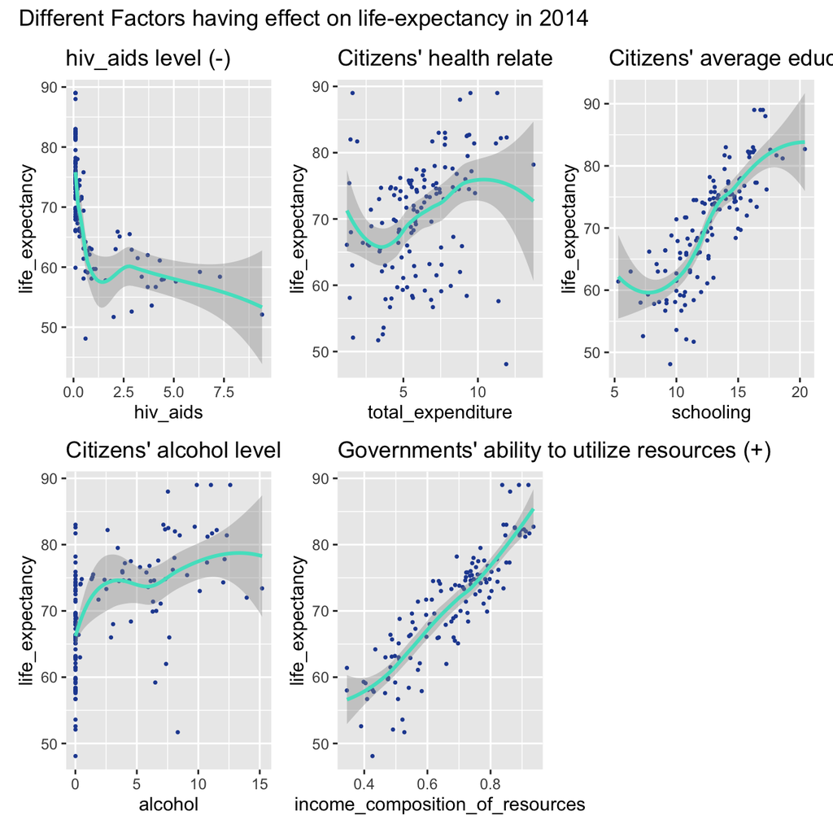

```r
#visualizing influence of significant features in the regression model

a <- ggplot(lc_2014, aes(x = hiv_aids, y = life_expectancy))+
  geom_point(colour="#234BA0",size=0.5)+
  geom_smooth(colour="#4FE1C8")+
  labs(title="hiv_aids level (-)",
       )


b <- ggplot(lc_2014, aes(x = total_expenditure, y = life_expectancy))+
  geom_point(colour="#234BA0",size=0.5)+
  geom_smooth(colour="#4FE1C8")+
  labs(title="Citizens' health related expenditure (+)")

c <- ggplot(lc_2014, aes(x = schooling, y = life_expectancy))+
  geom_point(colour="#234BA0",size=0.5)+
  geom_smooth(colour="#4FE1C8")+
  labs(title="Citizens' average education level (+)")

d <- ggplot(lc_2014, aes(x =alcohol, y = life_expectancy))+
  geom_point(colour="#234BA0",size=0.5)+
  geom_smooth(colour="#4FE1C8")+
  labs(title="Citizens' alcohol level (+)")

#Income composition of resources is a index that measures the government's ability to utilize its natural resources
e <- ggplot(lc_2014, aes(x =income_composition_of_resources, y = life_expectancy))+
  geom_point(colour="#234BA0",size=0.5)+
  geom_smooth(colour="#4FE1C8")+
  labs(title="Governments' ability to utilize resources (+)")

a+b+c+d+e + plot_annotation(
  title = "Different Factors having effect on life-expectancy in 2014"
)
```

Based on multi-variable linear regression result, we can see that, in 2014, Income Composition of Resources, and HIV rate significantly impacts the average life expectancy in a particular country. （We left out Adult Mortality to avoid perfect fit problem)